# Polling Places Report - Alabama

Author

Isabella Velásquez

Published

October 28, 2024

In this report, we present a detailed overview of polling places in various counties across the United States, providing information on the total number of polling places and showcasing example locations for each county on election day.[^1]

## Alabama

### Overview

- Total number of counties: **65**
- Total number of polling places: **2075**
- Election Day: **2020-11-03**

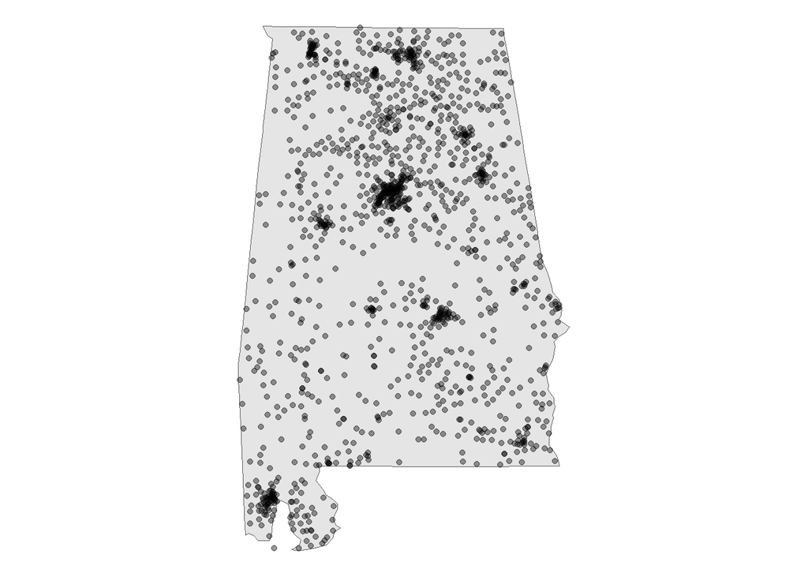

Figure 1: Polling locations in the state

### POLLING PLACES BY COUNTY

See polling place locations in Figure 1.

### AUTAUGA COUNTY

- Total Polling Places: 19
- Example Locations:

| name | address.x |
| --- | --- |
| AUTAUGAVILLE VOL FIRE DEPT | 2610 HIGHWAY 14 W, AUTAUGAVILLE, AL 36003 |
| BILLINGSLEY COMMUNITY CENTER | 2159 COUNTY RD 37, BILLINGSLEY, AL 36006 |
| BOONE’S CHAPEL | 2301 COUNTY RD 66, PRATTVILLE, AL 36067 |
| BOOTH VOL FIRE DEPT | 1701 COUNTY ROAD 10, BOOTH, AL 36008 |
| CAMELLIA BAPTIST CH | 201 WOODVALE ROAD, PRATTVILLE, AL 36067 |
| CENTRAL AL ELECTRIC COOP BLDG | 3613 HWY 14 W, AUTAUGAVILLE, AL 36003 |

### BALDWIN COUNTY

- Total Polling Places: 50
- Example Locations:

| name | address.x |
| --- | --- |
| PREC 1 - LITTLE RIVER VFD | 71250 STATE HIGHWAY 59, LITTLE RIVER, AL 36550 |
| PREC 2 - TENSAW NEW VFD | 65123 STATE HWY 59, STOCKTON, AL 36579 |
| PREC 3 - OLD VAUGHN SCHOOL | 55260 COUNTY RD 21, STOCKTON, AL 36579 |
| PREC 4 - CROSSROADS DURANT CHURCH | 9551 STATE HIGHWAY 138, BAY MINETTE, AL 36507 |
| PREC 5 - DOUGLASVILLE BOYKIN CTR | 900 B STILL BLVD, BAY MINETTE, AL 36507 |
| PREC 6 - BROMLEY VFD SUBST | 36625 STATE HIGHWAY 225, BAY MINETTE, AL 36507 |

### BARBOUR COUNTY

- Total Polling Places: 16
- Example Locations:

| name | address.x |
| --- | --- |
| BAKERHILL TOWN HALL | 1896 HIGHWAY 131, BAKER HILL, AL 36027 |
| BEVILL CENTER | 3223 S. EUFAULA AVENUE, EUFAULA, AL 36027 |
| BLUE SPRINGS CITY HALL | 2571 HIGHWAY 10, CLIO, AL 36017 |
| CLAYTON COURTHOUSE | 1 COURT SQUARE, CLAYTON, AL 36016 |
| CLIO CITY HALL | 3311 ELAMVILLE ST (HWY 51), CLIO, AL 36017 |
| ELAMVILLE V F D | 4109 HIGHWAY 51 SOUTH, ARITON, AL 36311 |

### BIBB COUNTY

- Total Polling Places: 8
- Example Locations:

| name | address.x |
| --- | --- |
| ALTERNATIVE SCHOOL | ALTERNATIVE SCH - WB, 456 CAHABA RIVER DRIVE, WEST BLOCTON, AL 35184 |
| BRENT CITY HALL | BRENT CITY HALL, 22 1ST STREET, BRENT, AL 35034 |
| EOLINE FIRE DEPT | EOLINE FIRE DEPT, 6480 HWY 82 WEST, CENTREVILLE, AL 35042 |
| GREENPOND FIRE DEPARTMENT | GREENPOND FIRE DEPARTMENT, 19639 EASTERN VALLEY ROAD, WOODSTOCK, AL 35188 |
| LAWLEY COMMUNITY CENTER | LAWLEY COMM CENTER, 2971 HIGHWAY 36, LAWLEY, AL 36793 |
| NATIONAL GUARD ARMORY | NATIONAL GUARD ARMORY, 185 WALNUT ST, CENTREVILLE, AL 35042, CENTREVILLE, AL 35042 |

### BLOUNT COUNTY

- Total Polling Places: 25
- Example Locations:

| name | address.x |
| --- | --- |
| ALLGOOD FIRE DEPARTMENT | 4535 OLD HWY 75, ONEONTA, AL 35121 |
| BLOUNT SPRINGS, RICETOWN FIRE DEPT | 241 RICE TOWN ROAD, HAYDEN, AL 35079 |
| BLOUNTSVILLE, TOWN HALL | 10017 LEE STREET W, BLOUNTSVILLE TOWN HALL, BLOUNTSVILLE, AL 35031 |
| BROOKSVILLE, PRECINCT 1001 COMMUNITY CENTER/FIRE | 81390 US HWY 278, BROOKSVILLE COMMUNITY CNTR/FIRE HALL, BLOUNTSVILLE, AL 35031 |
| CENTER SPRINGS BAPTIST CHURCH | 6516 CENTER SPRINGS RD, TRAFFORD, AL 35172 |
| CLEVELAND, PRECINCT 16 | 517 PARK ROAD, CLEVELAND COMMUNITY CENTER, CLEVELAND, AL 35049 |

### BULLOCK COUNTY

- Total Polling Places: 15
- Example Locations:

| name | address.x |
| --- | --- |
| ABERFOIL | 14473 HIGHWAY 29, UNION SPRINGS, AL 36089 |
| CORINTH | 3608 COUNTY RD 45, TROY, AL 36081 |
| CORNERSTONE | 261 BALLPARK RD, UNION SPRINGS, AL 36089 |
| FITZPATRICK | 9545 HIGHWAY 110, FITZPATRICK, AL 36029 |
| GUERRYTON | 26 SPARKS LN, HURTSBORO, AL 36860 |
| INDIAN CREEK | 2404 COUNTY RD 21, BANKS, AL 36005 |

### BUTLER COUNTY

- Total Polling Places: 22
- Example Locations:

| name | address.x |
| --- | --- |
| AMERICAN LEGION BUILDING | AMERICAN LEGION BUILDING, 100 AMERICAN LEGION DRIVE, GREENVILLE, AL 36037 |
| BOLLING VOTING HOUSE | 73 BOLLING ROAD, GEORGIANA, AL 36033 |
| CENTER HILL VOTING HOUSE | 15003 HALSO MILL ROAD, GREENVILLE, AL 36037 |
| CENTRAL FIRE DEPARTMENT | 3815 HALSO MILL ROAD, GREENVILLE, AL 36037 |
| CHAPMAN POST OFFICE | 12965 MOBILE RD, GEORGIANA, AL 36033 |
| DUNBAR CENTER | 208 SCHOOL HIGHLANDS ROAD, GREENVILLE, AL 36037 |

### CALHOUN COUNTY

- Total Polling Places: 46
- Example Locations:

| name | address.x |
| --- | --- |
| 1ST PRESBYTERIAN CHURCH | 1701 HENRY ROAD, ANNISTON, AL 36207 |
| ALEXANDRIA CIVITAN CLUB BLDG | 2273 ALEX-WELL ROAD, ALEXANDRIA, AL 36250 |
| ANGEL FIRE DEPT | 55 ANGEL STATION RD, JACKSONVILLE, AL 36265 |
| ANNISTON MEETING CENTER | 1615 NOBLE STREET, ANNISTON, AL 36201 |
| AP HOLLINGSWORTH COMMUNITY CENTER | 1552 AP HOLLINGSWORTH RD., WELLINGTON, AL 36279 |
| ASBERRY BAPTIST CHURCH | 3682 ROY WEBB RD., JACKSONVILLE, AL 36265 |

### CHAMBERS COUNTY

- Total Polling Places: 17
- Example Locations:

| name | address.x |
| --- | --- |
| BUFFALO 511/LEBANON CHURCH | 2090 CO RD 172, LAFAYETTE, AL 36862 |
| CUSSETA FIRE & RESCUE BUILDING 1201 | 4429 CO RD 299, CUSSETA, AL 36852 |
| FIVE POINTS COMMUNITY CLUB HOUSE 501 | 27031 HWY 431, FIVE POINTS, AL 36855 |
| FREDONIA FIRE & RESCUE UNIT 601 | 1047 CO RD 267, LANETT, AL 36863 |
| HUGULEY FIRE DEPT 13 | 5016 VETERANS MEMORIAL PARKWAY, LANETT, AL 36863 |
| LAFAYETTE HIGH SCHOOL GYM 801 | 214 FIRST AVE NE, LAFAYETTE, AL 36862 |

### CHEROKEE COUNTY

- Total Polling Places: 23
- Example Locations:

| name | address.x |
| --- | --- |
| BEREA CHURCH OF CHRIST | 3165 COUNTY ROAD 99, GAYLESVILLE, AL 35973 |
| BROOMTOWN VFD | 2340 COUNTY ROAD 46, GAYLESVILLE, AL 35973 |
| CEDAR BLUFF FIRST BAPT CH | 3500 OLD HWY 9, CEDAR BLUFF, AL 35959 |
| CONGREGATIONAL METHODIST CHURCH | 4815 COUNTY ROAD 14, CENTRE, AL 35960 |
| DANIEL’S CHAPEL | 8735 AL HWY 273, CEDAR BLUFF, AL 35959 |
| GAYLESVILLE TOWN HALL | 4740 MAIN STREET, GAYLESVILLE, AL 35973 |

### CHOCTAW COUNTY

- Total Polling Places: 41
- Example Locations:

| name | address.x |
| --- | --- |
| ARARAT | MORGAN CHAPEL BAPTIST CHURCH, 1629 ARARAT RD, BUTLER, AL 36904 |
| BARRYTOWN | GILBERTOWN CHURCH OF GOD, 3666 BARRYTOWN RD, GILBERTOWN, AL 36908 |
| BLADON SPRINGS | WILLIE CAMPBELL RESIDENCE (VOTING HOUSE), 3988 BLADON ROAD, SILAS, AL 36919 |
| BOGUELOOSA | NEEDHAM FIRE DEPARTMENT, 3696 NEEDHAM RD, NEEDHAM, AL 35915 |
| BRANCH SENATE 22 | SHADY GROVE BAPTIST CHURCH, 1760 SHADY GRAVE RD, SILAS, AL 36919 |
| BRANCH SENATE 24 | SHADY GROVE BAPTIST CHURCH, 1760 SHADY GROVE RD, SILAS, AL 36919 |

### CLARKE COUNTY

- Total Polling Places: 29
- Example Locations:

| name | address.x |
| --- | --- |
| ANTIOCH FIRE STATION | 10171 HIGHWAY 43, GROVE HILL, AL 36451 |
| BASHI METHODIST CHURCH | 8849 BASHI ROAD, THOMASVILLE, AL 36784 |
| CHILTON BAPTIST CHURCH | 5834 CHILTON ROAD, GROVE HILL, AL 36451 |
| CHOCTAW BLUFF ALMA FIRE STATION | 361 CHOCTAW BLUFF ROAD, JACKSON, AL 36545 |
| COFFEEVILLE HIGH SCHOOL | 22974 HWY 69, COFFEEVILLE, AL |
| FULTON FIRE STATION | 140 MAIN ST, FULTON, AL 36446 |

### CLAY COUNTY

- Total Polling Places: 25
- Example Locations:

| name | address.x |
| --- | --- |
| BARFIELD VOLUNTEER FIRE DEPT PRECINCT 00301 | 38 BARFIELD FIRE DEPT RD, LINEVILLE, AL 36266 |
| BIBB GRAVES / COMMUNITY CTR 00801 | 334 SCHOOLHOUSE RD, ASHLAND, AL 36251 |
| BIBB GRAVES / COMMUNITY CTR 02301 | 334 SCHOOLHOUSE RD, ASHLAND, AL 36251 |
| BLUFF SPRINGS FIRE DEPARTMENT 01401 | 7637 BLUFF SPRINGS RD, ASHLAND, AL 36251 |
| CLAY CO FARMERS MARKET 00401 | 86838 HIGHWAY 9, LINEVILLE, AL 36266 |
| CLAY CO FARMERS MARKET 01301 | 86838 HIGHWAY 9, LINEVILLE, AL 36266 |

### CLEBURNE COUNTY

- Total Polling Places: 14
- Example Locations:

| name | address.x |
| --- | --- |
| ABEL | 4234 CO RD 24, DELTA, AL 36258 |
| BORDEN SPRINGS | 39155 CO RD 49, PIEDMONT, AL 36272 |
| CHULAFINNEE (A-Z) | 2830 CO RD 11, HEFLIN, AL 36264 |
| EDWARDSVILLE | 4024 TALLAPOOSA ST, HEFLIN, AL 36264 |
| FRUITHURST | 16201 HWY 78, FRUITHURST, AL 36262 |
| GREENS CHAPEL/BEASONS MILL | 6867 CO RD 36, HEFLIN, AL 36264 |

### COFFEE COUNTY

- Total Polling Places: 29
- Example Locations:

| name | address.x |
| --- | --- |
| BASIN | 9896 HIWAY 189, ELBA, AL 36323 |
| BLUFF SPRINGS | 4011 COUNTY RD 305, ELBA, AL 36323 |
| CHESTNUT GROVE | 1701 COUNTY RD 110, JACK, AL 36346 |
| COOL SPRINGS VOLUNTEER FIRE DEPT | 3215 COUNTY RD 708, ENTERPRISE, AL 36330 |
| DAMASCUS SENIOR CENTER | 127 COUNTY RD 514, ELBA, AL 36323 |
| EANON | 3605 COUNTY RD 148, NEW BROCKTON, AL 36351 |

### COLBERT COUNTY

- Total Polling Places: 35
- Example Locations:

| name | address.x |
| --- | --- |
| ALLSBORO CUMB. PRESB. CH | 4850 ALLSBORO RD, CHEROKEE, AL 35616 |
| BARTON FIRST BAPTIST | 12925 HWY 72, CHEROKEE, AL 35616 |
| C.H. 1ST BAPTIST CHURCH | 6000 WOODMONT DR, TUSCUMBIA, AL 35674 |
| CALVARY BAPTIST CHURCH | 601 N. MAIN ST., TUSCUMBIA, AL 35674 |
| CAVE SPRINGS MISS BAPT CH | 3217 E.6TH STREET, TUSCUMBIA, AL 35674 |
| CHEROKEE LION DEN | 130 CHURCH ST, CHEROKEE, AL 35616 |

### CONECUH COUNTY

- Total Polling Places: 32
- Example Locations:

| name | address.x |
| --- | --- |
| \ | 9309 COUNTY ROAD 43, EVERGREEN, AL 36401 |
| 0522 LENOX COMMUNITY HOUSE | 4848 COUNTY ROAD 6, REPTON, AL 36475 |
| 2ND MOUNT ZION CHURCH | 5386 OWASSA RD, EVERGREEN, AL 36401 |
| 2ND MOUNT ZION CHURCH A | 5386 OWASSA RD, EVERGREEN, AL 36401 |
| ANNEX VOTING HOUSE | 6257 CO RD 106, MCKENZIE, AL 36456 |
| BEAT 8 FIRE DEPARTMENT | 3362 COUNTY ROAD 24, EVERGREEN, AL 36401 |

### COOSA COUNTY

- Total Polling Places: 12
- Example Locations:

| name | address.x |
| --- | --- |
| COMMUNITY LIFE CENTER | 188 COOSA COUNTY RD 30, KELLYTON, AL 35089 |
| EQUALITY UNITED METHODIST CHURCH NEW FELLOWSHIP HA | 281 AL HWY 259, EQUALITY, AL 36026 |
| GOODWATER COMMUNITY CENTER | 22012 AL HWY 9, GOODWATER, AL 35072 |
| HANOVER | 17294 US HWY 231, ROCKFORD, AL 35136 |
| KELLYTON CIVIC COMPLEX CAFETERIA | 179 CHURCH STREET, KELLYTON, AL 35089 |
| MARBLE VALLEY FIRE DEPT | 2373 COOSA COUNTY ROAD 5, SYLACAUGA, AL 35150 |

### COVINGTON COUNTY

- Total Polling Places: 25
- Example Locations:

| name | address.x |
| --- | --- |
| ANDALUSIA | 20096 KIWANIS DRIVE, ANDALUSIA, AL 36420 |
| BABBIE | 22543 BABBIE ROAD, ANDALUSIA, AL 36421 |
| BEULAH | 16612 MAGGIE ROAD, OPP, AL 35467 |
| BLUE SPRINGS | 18692 HORN HILL ROAD, OPP, AL 35467 |
| BUCK CREEK | 34928 HESTERS STORE ROAD, RED LEVEL, AL 36474 |
| CAROLINA | 19250 ROCKHOLE BRIDGE ROAD, ANDALUSIA, AL 36420 |

### CRENSHAW COUNTY

- Total Polling Places: 18
- Example Locations:

| name | address.x |
| --- | --- |
| BRANTLEY COMMUNITY CENTER | 81 MAPLE ST, BRANTLEY, AL 36009 |
| BUSH’S GROCERY | 12360 DOZIER HWY, BRANTLEY, AL 36009 |
| CHAPEL HILL BAPTIST CHURCH | 2146 CHAPEL HILL ROAD, RUTLEDGE, AL 36071 |
| CRENSHAW COUNTY COURTHOUSE | 29 S GLENWOOD AVE, LUVERNE, AL 36049 |
| DANIELVILLE BAPTIST CHURCH | 91 DANIELVILLE ROAD, HONORAVILLE, AL 36042 |
| DOZIER TOWN HALL | 7874 S MAIN ST, DOZIER, AL 36028 |

### CULLMAN COUNTY

- Total Polling Places: 49
- Example Locations:

| name | address.x |
| --- | --- |
| ARKADELPHIA FIRE DEPARTMENT | 4990 COUNTY ROAD 35, BREMEN, AL 35033 |
| BAILEYTON SENIOR CENTER | 195 FIRE STATION RD, BAILEYTON, AL 35019 |
| BALDWIN FAMILY LIFE CENTER | 110 COUNTY ROAD 1153, CULLMAN, AL 35057 |
| BATTLEGROUND FIRE DEPARTMENT | 239 COUNTY ROAD 1101, VINEMONT, AL 35179 |
| BEAT 8 COMMUNITY CENTER | 63 COUNTY ROAD 15, BREMEN, AL 35033 |
| BERLIN COMMUNITY CENTER | 3309 AL HWY 278 EAST, CULLMAN, AL 35058 |

### DALE COUNTY

- Total Polling Places: 20
- Example Locations:

| name | address.x |
| --- | --- |
| ARGUTA/COMMUNITY CENTER | 4026 COUNTY RD 13, OZARK, AL 36360 |
| ARITON/CITY HALL | 224 E. MAIN STREET, ARITON, AL 36311 |
| BERTHA/NEW HOPE BAPTIST CHURCH ACTIVITY BUILDING | 4239 COUNTY RD 69, SKIPPERVILLE, AL 36374 |
| CLAYHATCHEE/COMMUNITY HOUSE | 750 W. MAIN STREET, DALEVILLE, AL 36322 |
| CLOPTON/COMMUNITY HOUSE | 13662 HIGHWAY 105, SKIPPERVILLE, AL 36379 |
| DALEVILLE/CULTURAL AND CONVENTION CENTER | 730 S. DALEVILLE AVE, DALEVILE, AL 36322 |

### DALLAS COUNTY

- Total Polling Places: 30
- Example Locations:

| name | address.x |
| --- | --- |
| BARRETT RD METH CHURCH (CITY BOX D51W) | 615 BARRETT ROAD, SELMA, AL 36701 |
| BARRETT RD METH CHURCH (CTY BOX 0901) | 615 BARRETT ROAD, SELMA, AL 36701 |
| BELOIT COMMMUNITY CENTER - 0402 | 8010 AL HWY 22 W, ORRVILLE, AL 36767 |
| BROAD STREET FIRE STATION - D37E | 1500 BROAD ST, SELMA, AL 36703 |
| CARLOWVILLE/MINTER VFD - 1501 | 102 DALLAS RD 4, MINTER, AL 36761 |
| CARVER NEIGHBORHOOD CENTER - D18W | 207 MARTIN LUTHER KING JR. STREET, SELMA, AL 36703 |

### DEKALB COUNTY

- Total Polling Places: 45
- Example Locations:

| name | address.x |
| --- | --- |
| ADAMSBURG FIRE DEPT | 5134 CO RD 78, FORT PAYNE, AL 35967 |
| ARONEY FIRE DEPT | 80 CO RD 203, BOAZ, AL 35957 |
| BLAKE COMM CTR | 464 CO RD 505, FORT PAYNE, AL 35968 |
| CARTERSVILLE FIRE DEPT | 4894 AL HWY 75, FLAT ROCK, AL 35966 |
| COLLINSVILLE-NAT’L GRD BLDG | 3210 AL HWY 68, COLLINSVILLE, AL 35961 |
| COPELAND BRIDGE-LIBERTY HILL | 68 CO RD 283, COLLINSVILLE, AL 35961 |

### ELMORE COUNTY

- Total Polling Places: 30
- Example Locations:

| name | address.x |
| --- | --- |
| ASBURY-KENT COMMUNITY CENTER 0041 | 2872 KENT RD |
| BLUE RIDGE BAPTIST CHURCH 0321 | 4471 JASMINE HILL RD |
| CAINS CHAPEL LIFE CENTER 0151 | 96 LIGHTWOOD ROAD |
| COOSADA TOWN HALL 0201 | 5800 COOSADA RD |
| CRENSHAW PARK 0171 | 1371 CRENSHAW RD |
| DEATSVILLE VOL FIRE DEPT 0161 | 6930 AL HWY 143 |

### ESCAMBIA COUNTY

- Total Polling Places: 29
- Example Locations:

| name | address.x |
| --- | --- |
| ALCO JD MUSEUM | 220 ALCO DR, BREWTON, AL 36426 |
| APPLETON VOLUNTEER FIRE DEPT. | 1009 APPLETON RD, BREWTON, AL 36426 |
| ATMORE CITY HALL | 201 EAST LOUISVILLE AVENUE, ATMORE, AL 36502 |
| ATMORE PUBLIC LIBRARY | 700 EAST CHURCH STREET, ATMORE, AL 36502 |
| BARNETT’S CROSSROAD | 700 BARNETT HWY, BREWTON, AL 36426 |
| BETHEL ROBERTS - ROBERTS VOLUNTEER FIRE DEPT. | 6615 BRADLEY RD, ANDALUSIA, AL 36420 |

### ETOWAH COUNTY

- Total Polling Places: 32
- Example Locations:

| name | address.x |
| --- | --- |
| ALTOONA FIRE DEPARTMENT | 3680 MAIN ST, ALTOONA, AL 35952 |
| ATTALLA RECREATION CENTER | 115 CASE AVE, ATTALLA, AL 35954 |
| CARVER COMMUNITY CENTER | 1030 TUSCALOOSA AVE, GADSDEN, AL 35901 |
| CAVE SPRINGS COMMUNITY CLUB HOUSE | 3758 DUCK SPRINGS RD., ATTALLA, AL 35954 |
| DOWNTOWN CIVIC CENTER | 623 BROAD ST, GADSDEN, AL 35901 |
| EAST GADSDEN RECREATION CENTER | 919 WILSON AVE., EAST GADSDEN, AL 35903 |

### FAYETTE COUNTY

- Total Polling Places: 26
- Example Locations:

| name | address.x |
| --- | --- |
| BERRY CIVIC CENTER | 59 SCHOOL AVE, BERRY, AL 35546 |
| BOLEY/BOLEY SPRINGS VOLUNTEER FIRE DEPT | 3828 CO RD 83, BERRY, AL 35546 |
| BROWNS/GLEN ALLEN TOWN HALL | 42 BIRCH ST, GLEN ALLEN, AL 35559 |
| BROWNS/WHITES CHAPEL VOTING CENTER | 5121 CO RD 24, WINFIELD, AL 35594 |
| BYLOR/BANKSTON VOTING CENTER | 10385 HWY 18E, BANKSTON, AL 35542 |
| CLEAR CREEK/CEDAR GROVE CHURCH-MOORE HALL | 80 CO RD 49 @ INTERSECTION OF CO RD 93/49, BANKSTON, AL 35542 |

### FRANKLIN COUNTY

- Total Polling Places: 40
- Example Locations:

| name | address.x |
| --- | --- |
| BELGREEN 7/1 CS3 | BELGREEN FIRE DEPT, 4325 HIGHWAY 524, RUSSELLVILLE, AL 35653 |
| BELGREEN 7/1 CS4 | BELGREEN FIRE DEPT, 4325 HIGHWAY 524, RUSSELLVILLE, AL 35653 |
| CHURNTOWN 19/1 CS1 | CORNERSTONE FELLOWSHIP CHURCH, 1 BLOCK CHURCH RD, PHIL CAMPBELL, AL 35581 |
| CHURNTOWN 19/2 CS1 | CORNERSTONE FELLOWSHIP CHURCH, 1 BLOCK CHURCH RD, PHIL CAMPBELL, AL 35581 |
| CHURNTOWN 19/2 CS2 | CORNERSTONE FELLOWSHIP CHURCH, 1 BLOCK CHURCH RD, PHIL CAMPBELL, AL 35581 |
| FRANKFORT 3/1 CS4 | FRANKFORT COMMUNITY CTR, 7454 HIGHWAY 49, RUSSELLVILLE, AL 35653 |

### GENEVA COUNTY

- Total Polling Places: 21
- Example Locations:

| name | address.x |
| --- | --- |
| BELLWOOD | BELLWOOD COMMUNITY CENTER, 4931 COUNTY ROAD 45, BELLWOOD, AL 36313 |
| BLACK | BLACK COMMUNITY CENTER, 558 N CURTIS ST, BLACK, AL 36314 |
| CHANCELLOR | EL BETHEL BAPTIST CHURCH, 9432 N STATE HIGHWAY 27, CHANCELLOR, AL 36316 |
| COFFEE SPRINGS | JOY LIFE CENTER, 177 E BAXLEY ST, COFFEE SPGS, AL 36318 |
| DEVCO VOTING HOUSE | DEVCO VOTING HOUSE, 305 S WARD ST, GENEVA, AL 36340 |
| FADETTE | FADETTE COMMUNITY BLDG, 5307 S STATE HIGHWAY 103, SLOCOMB, AL 36375 |

### GREENE COUNTY

- Total Polling Places: 14
- Example Locations:

| name | address.x |
| --- | --- |
| BOLIGEE FIRE STATION (A-Z) | 17176 CO. RD. 20, BOLIGEE, AL 35443 |
| BROWN MORROW BRANCH HGTS CENTR | 429 BRANCH HEIGHTS DR, EUTAW, AL 35462 |
| CLINTON COMMUNITY CENTER (A-Z) | 58 CO. RD. 117, CLINTON, AL 35448 |
| EUTAW ACTIVITY CENTER (A-Z) | 107 HARRIS AVE, EUTAW, AL 35462 |
| FORKLAND CITY HALL (A-Z) | 13327 US HWY 43, FORKLAND, AL 36740 |
| GREENE COUNTY COURTHOUSE (A-Z) | 400 MORROW AVE, EUTAW, AL 35462 |

### HALE COUNTY

- Total Polling Places: 14
- Example Locations:

| name | address.x |
| --- | --- |
| AKRON CITY HALL | 207 1ST AVE SOUTH, AKRON, AL 35441 |
| BUCKSNORT | 12045 CO RD 32, GREENSBORO, AL 36744 |
| HAVANA | 426 CO RD 37, MOUNDVILLE, AL 35474 |
| LOCK 5 VOLUNTEER FIRE DEPT BUILDING | 13286 COUNTY RD 16, GREENSBORO, AL 36744 |
| MOUNDVILLE CITY HALL | 410 MARKET STREET, MOUNDVILLE, AL 35474 |
| MOUNT HERMAN #2 | 24739 AL HWY 25, GREENSBORO, AL 36744 |

### HENRY COUNTY

- Total Polling Places: 14
- Example Locations:

| name | address.x |
| --- | --- |
| BALKUM BAPTIST CHURCH | 1153 COUNTY ROAD 55, HEADLAND, AL 36345 |
| CAPPS POST OFFICE (A-Z) | 1996 ST HWY 173, NEWVILLE, AL 36353 |
| DOUGLAS CROSS ROADS | 2203 CO RD 63, COLUMBIA, AL 36319 |
| EDWIN VOTING HOUSE | 4990 CO RD 75 N, CLOPTON, AL 36317 |
| GREATER SHILOH BAPTIST CHURCH | 12 MARTIN LUTHER DRIVE, HEADLAND, AL 36345 |
| HALEBURG CITY HALL | 1396 MAIN ST, COLUMBIA, AL 36319 |

### HOUSTON COUNTY

- Total Polling Places: 28
- Example Locations:

| name | address.x |
| --- | --- |
| *** OUT OF COUNTY *** | UNKNOWN, AL |
| ANDREW BELLE COMM CENTER | 1270 LAKE STREET, DOTHAN, AL 36303 |
| BAY SPRINGS VOL FIRE DEPT | 1500 SOUTH BAY SPRINGS ROAD, DOTHAN, AL 36305 |
| COTTONWOOD CITY HALL | 1414 METCALF STREET, COTTONWOOD, AL 36320 |
| COWARTS BAPTIST CHURCH FLC | 2819 JORDON AVE, COWARTS, AL 36321 |
| DOTHAN CIVIC CENTER | 126 N. SAINT ANDREWS ST., DOTHAN, AL 36303 |

### JACKSON COUNTY

- Total Polling Places: 36
- Example Locations:

| name | address.x |
| --- | --- |
| ASPEL JACKSON CO WATERWORKS | 14676 US HWY 72, SCOTTSBORO, AL 35768 |
| BISHOP HALL’S STORE | 241 COUNTY ROAD 9, ESTILLFORK, AL 35745 |
| BRIDGEPORT SENIOR CENTER | 411 ALABAMA AVE, BRIDGEPORT, AL 35740 |
| BRYANT COMMUNITY BUILDING | 6745 AL HWY 73, BRYANT, AL 35958 |
| CHRISTIAN HOME CAPERTON’S CHAPEL | 213 CO RD 14, FLAT ROCK, AL 35966 |
| CROW FIRE HALL | 8548 CO RD 39, FACKLER, AL 35746 |

### JEFFERSON COUNTY

- Total Polling Places: 172
- Example Locations:

| name | address.x |
| --- | --- |
| PREC 1010 - OUR LADY OF LOURDES CATHOLIC CHURCH | 980 HUFFMAN RD, BIRMINGHAM, AL 35215 |
| PREC 1020 - TOM BRADFORD PARK | 1701 EDWARDS LAKE RD, BIRMINGHAM, AL 35235 |
| PREC 1030 - L.M. SMITH MIDDLE SCHOOL | 1124 FIVE MILE RD, BIRMINGHAM, AL 35215 |
| PREC 1040 - BETHEL BAPTIST CHURCH | 1708 SPENCER AVE, BIRMINGHAM, AL 35214 |
| PREC 1050 - MIDFIELD COMMUNITY CENTER | 416 WOODWARD RD, BIRMINGHAM, AL 35228 |
| PREC 1060 - SUN VALLEY ELEMENTARY SCHOOL | 1010 18TH AVE NW, BIRMINGHAM, AL 35215 |

### LAUDERDALE COUNTY

- Total Polling Places: 31
- Example Locations:

| name | address.x |
| --- | --- |
| ANDERSON GYMNASIUM | 6 SCHOOL ROAD, ANDERSON, AL 35610 |
| ATLAS CHURCH OF CHRIST | 3461 COUNTY ROAD 73, KILLEN, AL 35645 |
| BROADWAY REC. CENTER | 300 BROADWAY ST., FLORENCE, AL 35630 |
| CENTER STAR FIRST BAPTIST CHURCH | 6620 HWY 72, KILLEN, AL 35645 |
| CENTRAL BAPTIST CHURCH | 1600 HUNTSVILLE RD, FLORENCE, AL 35630 |
| CENTRAL COMMUNITY CENTER | 3276 CO. RD. 6, FLORENCE, AL 35633 |

### LAWRENCE COUNTY

- Total Polling Places: 36
- Example Locations:

| name | address.x |
| --- | --- |
| BOARD OF EDUCATION 25 | 14131 MARKET ST, MOULTON, AL 35650 |
| CADDO FIRE STATION 33 | 7909 COUNTY ROAD 214, TRINITY, AL 35673 |
| CADDO SENIOR CENTER 34 | 6229 COUNTY ROAD 214, TRINITY, AL 35673 |
| CHALYBEATE FIRE STATION 17 | 69 COUNTY ROAD 296, HILLSBORO, AL 35643 |
| DONALD CHURCH 7 | 3065 COUNTY ROAD 143, TOWN CREEK, AL 35672 |
| DONALD CHURCH 8 | 3065 COUNTY ROAD 143, TOWN CREEK, AL 35672 |

### LEE COUNTY

- Total Polling Places: 22
- Example Locations:

| name | address.x |
| --- | --- |
| 01/0 - BEULAH HIGH SCHOOL LOBBY | 4848 LEE ROAD 270, VALLEY, AL 36854 |
| 02/1 - COVINGTON PARK COMMUNITY CENTER | 213 CARVER AVE, OPELIKA, AL 36801 |
| 02/2 - OPELIKA LEARNING CENTER | 214 JETER AVE, OPELIKA, AL 36801 |
| 02/3 - OPELIKA REC. CENTER | 1102 DENSON DR, OPELIKA, AL 36801 |
| 02/4 - EAMC EDUCATION CENTER | 2027 PEPPERELL PKWY, OPELIKA, AL 36801 |
| 02/5 - OPELIKA SPORTSPLEX | 1001 ANDREWS RD, OPELIKA, AL 36801 |

### LIMESTONE COUNTY

- Total Polling Places: 25
- Example Locations:

| name | address.x |
| --- | --- |
| 0101 ATHENS RECREATION CENTER | 21821 SPORTSPLEX LOOP, ATHENS, AL 35613 |
| 0102 LINDSAY LANE BAPTIST CHURCH | 1300 LINDSAY LANE S, ATHENS, AL 35613-2708 |
| 0103 PINCHAM-LINCOLN CENTER | 606 TRINITY CIRCLE, ATHENS, AL 35611 |
| 0104 FRIENDSHIP UM CHURCH | 16479 LUCAS FERRY RD, ATHENS, AL 35611 |
| 0105 ATHENS SENIOR CENTER | 912 WEST PRYOR ST, ATHENS, AL 35611 |
| 0106 ELKTON ROAD BAPTIST CHURCH | 19470 ELKTON RD, ATHENS, AL 35614-6277 |

### LOWNDES COUNTY

- Total Polling Places: 12
- Example Locations:

| name | address.x |
| --- | --- |
| BETHEL CHURCH - PRECINCT 3.1 | 8375 COUNTY ROAD 12, TYLER, AL 36785 |
| BURKVILLE VOLUNTEER FIRE DEPT - PREC 7.1 | 795 COUNTY ROAD 37 SOUTH, HOPE HULL, AL 36043 |
| CALHOUN VOLUNTEER FIRE DEPT. | 6654 COUNTY ROAD 33, LETOHATCHEE, AL 36047 |
| HAYNEVILLE COURTHOUSE ANNEX - PRECINCT 6.1 | 205 TUSKEENA STREET EAST, DOWNSTAIRS - 1ST FLOOR, HAYNEVILLE, AL 36040 |
| LILY BAPTIST CHURCH | 7235 STATE HIGHWAY 97 SOUTH, LETOHATCHEE, AL 36047 |
| LOWNDES COUNTY ECONOMIC DEVELOP. OFFICE | 8891 COUNTY ROAD 26, HOPE HULL, AL 36043 |

### MACON COUNTY

- Total Polling Places: 15
- Example Locations:

| name | address.x |
| --- | --- |
| BROWNVILLE VOL FIRE | 350 ROGERS RD, TUSKEGEE, AL 36083 |
| CHISHOLM COMMUNITY CENTER | 3031 COUNTY ROAD 69, TUSKEGEE, AL 36083 |
| COTTON VALLEY RECREATION CENTER | 11425 US HWY 29 SOUTH, TUSKEGEE, AL 36083 |
| D-2 RECREATION CENTER | CO RD 5, WARRIOR STAND, AL |
| DIST 3 VOL FIRE DEPT | 10365 US HWY 80 WEST, SHORTER, AL 36075 |
| DISTRICT 4 COMMUNITY CENTER | 351 LORI LANE, NOTASULGA, AL 36866 |

### MADISON COUNTY

- Total Polling Places: 72
- Example Locations:

| name | address.x |
| --- | --- |
| PCT. 01 - A & M UNIVERSITY NEW GYM | 4900 MERIDIAN ST NW, NORMAL, AL 35762 |
| PCT. 02 - CHARLES STONE AGRICULTURAL CTR | 819 COOK AVENUE, HUNTSVILLE, AL 35801 |
| PCT. 03 - JACKSON WAY BAPTIST CHURCH | 1001 ANDREW JACKSON WAY NE, HUNTSVILLE, AL 35801 |
| PCT. 04 - FIRST BAPTIST CHURCH | 600 GOVERNORS DR, HUNTSVILLE, AL 35801 |
| PCT. 05 - OPTIMIST PARK REC. CENTER | 703 OAKWOOD AVENUE NE, HUNTSVILLE, AL 35811 |
| PCT. 06 -NE HUNTSVILLE TRAINING&CONFERENCE CENTER | 2135 US HWY 72, HUNTSVILLE, AL 35811 |

### MARENGO COUNTY

- Total Polling Places: 19
- Example Locations:

| name | address.x |
| --- | --- |
| CHURCH AFLAME | 431 HWY 80 W, DEMOPOLIS, AL 36732 |
| DEMOPOLIS CIVIC CENTER | 501 NORTH COMMISSIONER AVE, DEMOPOLIS, AL 36732 |
| DEMOPOLIS OLD NAT’L GUARD ARMORY | 1701 HWY 43 S, DEMOPOLIS, AL 36732 |
| DIXON MILLS VFD | 3846 COUNTY ROAD 6, DIXONS MILLS, AL 36736 |
| FAUNSDALE TOWN HALL | 35527 AL HWY 25, FAUNSDALE, AL 36738 |
| FLATWOODS | 375 FLATWOOD CIRCLE, CATHERINE, AL 36728 |

### MARION COUNTY

- Total Polling Places: 23
- Example Locations:

| name | address.x |
| --- | --- |
| ( ABOVE UNION HALL NEAR MITCHELL’S GROC ( BACCUS) | 5171 CO HWY 38 , WINFIELD, PRECINCT 13 ( BACCUS), WINFIELD, AL 35594 |
| (HOWELL) SULLINS CHURCH HOUSE | 4157 CO HWY 49, HAMILTON, PRECINCT 10 (HOWELL), HAMILTON, AL 35570 |
| (KIMBROUGH) CRAFT COMM CENTER (N) | 7109 COUNTY HWY 19, HALEYVILLE, PRECINCT 9 N (KIMBROUGH), HALEYVILLE, AL 35565 |
| (KIMBROUGH) CRAFT COMM CENTER (S) | 7109 CO HWY 19, HALEYVILLE, PRECINCT 9 S (KIMBROUGH), HALEYVILLE, AL 35565 |
| (PEARCE MILL) PEA RIDGE FIRE DEPT | 5710 CO HWY 45, GUIN, PRECINCT 11 (PEARCE MILL), GUIN, AL 35563 |
| (WIGINTON) COMM. BLDG OFF HWY 172 | 2665 CO HWY 53, HACKLEBURG, PRECINCT 19 (WIGINTON), HACKLEBURG, AL 35564 |

### MARSHALL COUNTY

- Total Polling Places: 29
- Example Locations:

| name | address.x |
| --- | --- |
| ALBERTVILLE / 1ST BAPTIST CHURCH | 309 EAST MAIN STREET, ALBERTVILLE, AL 35950 |
| ARAB SENIOR CENTER | 800 NORTH MAIN STREET, ARAB, AL 35016 |
| BOAZ REC CENTER | 314 NORTH KING STREET, BOAZ, AL 35957 |
| BOSHART / PROSPECT CEMETERY | BOSHART PROSPECT CEMETERY, 4885 SCOTTSBORO HWY, SCOTTSBORO, AL 35769 |
| BUCKSNORT COMMUNITY CENTER | OLD MT PLEASANT SCHOOL, 5958 SIMPSON POINT ROAD, GRANT, AL 35747 |
| CLAYSVILLE / HENRYVILLE METHODIST CHURCH | 22520 US HWY 431, GUNTERSVILLE, AL 35976 |

### MOBILE COUNTY

- Total Polling Places: 85
- Example Locations:

| name | address.x |
| --- | --- |
| 001 - BETHEL BAPTIST CHURCH | 16641 PRINE ROAD, CITRONELLE, AL 36522 |
| 002 - MEMORIAL BAPTIST CHURCH | 19655 MOBILE STREET NORTH, CITRONELLE, AL 36522 |
| 004 - BELSAW MT. VERNON SCHOOL | 1650 GARTMAN CIRCLE, MT VERNON, AL 36560 |
| 005 - MCDAVID JONES ELEMENTARY | 16250 HWY 45, CITRONELLE, AL 36522 |
| 006 - TURNERVILLE BAPTIST CHURCH | 13882 ROBERTS RD, CHUNCHULA, AL 36521 |
| 007 - 1ST BAPTIST CHURCH WILMER - GYM | 13371 MOFFETT RD, WILMER, AL 36587 |

### MONROE COUNTY

- Total Polling Places: 30
- Example Locations:

| name | address.x |
| --- | --- |
| ANTIOCH BAPTSTIST CHURCH #3 | 10131 THE RIDGE ROAD, MONROEVILLE, AL 36460 |
| BEAT 1 FIRE DEPT/ELISKA CHRYSLER | 12243 HWY 59S, URIAH, AL 36480 |
| BETHANY BAPTIST CHURCH | 7238 COUNTY ROAD 30, PETERMAN, AL 36471 |
| BETHEL BAPTIST CHURCH | 1040 CLAUSELL RD, MONROEVILLE, AL 36460 |
| BUENA VISTA/VREDENBURG FD | 69 WALNUT ST., VREDENBURGH, AL 36481 |
| CHURCH OF CHRIST | 353 HWY 136W, MONNROEVILLE, AL 36460 |

### MONTGOMERY COUNTY

- Total Polling Places: 50
- Example Locations:

| name | address.x |
| --- | --- |
| 101 - DRUM THEATER / HUNTINGDON | 1125 E FAIRVIEW AVE, MONTGOMERY, AL 36106 |
| 102 - VAUGHN PARK CHURCH | 3800 VAUGHN ROAD, MONTGOMERY, AL 36106 |
| 103 - MONTGOMERY MUSEUM OF FINE ARTS | ONE MUSEUM DRIVE, MONTGOMERY, AL 36117 |
| 104 - WHITFIELD UMC | 2673 FISK RD, MONTGOMERY, AL 36111 |
| 105 - ALDERSGATE UMC | 6610 VAUGHN ROAD, MONTGOMERY, AL 36116 |
| 106 - CITY OF REFUGE CHURCH | 3820 WOODLEY RD., MONTGOMERY, AL 36116 |

### MORGAN COUNTY

- Total Polling Places: 39
- Example Locations:

| name | address.x |
| --- | --- |
| AMERICAN LEGION BUILDING POST 15 | 2607 HIGHWAY 31 S, DECATUR, AL 35603 |
| AQUADOME RECREATION CENTER | 1202 5TH AVE SW, DECATUR, AL 35601 |
| CARRIE MATTHEWS REC. CENTER | 902 6TH ST NW, DECATUR, AL 35601 |
| CENTER SPRINGS METHODIST CHURCH | 4851 E UPPER RIVER RD, SOMERVILLE, AL 35670 |
| COTACO FIRE STATION | 6463 HIGHWAY 36 E, SOMERVILLE, AL 35670 |
| DANVILLE VOLUNTEER FIRE STATION | 5796 HIGHWAY 36 W, DANVILLE, AL 35619 |

### PERRY COUNTY

- Total Polling Places: 19
- Example Locations:

| name | address.x |
| --- | --- |
| A-Z NORTH PERRY FIRE STATION | 13525 CORETTA SCOTT KING HWY, MARION, AL 36756 |
| CLB | 270 LUCIAN ST, UNIONTOWN, AL 36786 |
| EPFD -DIST 3 - HD 67 | AL |
| HAMBURG VOLUNTEER FIRE DEPARTMENT 72 | 7250 ALBERT TURNER SR MEM HWY, MARION, AL 36756 |
| HAMBURG VOLUNTEER FIRE DEPARTMENT 67 | 7250 ALBERT TURNER SR MEM HWY, MARION, AL 36756 |
| HEIBERGER CAFE’ | 23470 HIGHWAY 5 NORTH ,PERRY COUNTY ALABAMA, MARION, AL 36756 |

### PICKENS COUNTY

- Total Polling Places: 23
- Example Locations:

| name | address.x |
| --- | --- |
| ALICEVILLE ARMORY - 2200 | ALICEVILLE, 5398 MEMORIAL PARKWAY, ALICEVILLE, AL 35447-3544 |
| ALICEVILLE ARMORY - 5500 | 5398 MEMORIAL PARKWAY, ALICEVILLE, AL 35442 |
| BENEVOLA COMMUNITY CENTER | 13974 COUNTY ROAD 2, GORDO, AL 35466 |
| BETHLEHEM VOTING CENTER | 161 BILL TAYLOR RD, MILLPORT, AL 35576 |
| CARROLLTON SERVICE CENTER - CONGRESSIONAL 4 | 155 REFORM STREET, CARROLLTON, AL 35447 |
| CARROLLTON SERVICE CENTER - CONGRESSIONAL 7- 4200 | 155 REFORM STREET, CARROLLTON, AL 35447 |

### PIKE COUNTY

- Total Polling Places: 38
- Example Locations:

| name | address.x |
| --- | --- |
| 01 TROY PUBLIC LIBRARY | 500 E WALNUT STREET, TROY, AL 36081 |
| 02 MEEKSVILLE- VOLUNTEER FIRE DEPT. | 2699 COUNTY ROAD 7714, TROY, AL 36081 |
| 03 CHINA GROVE-COUNTY BLDG. | METAL COUNTY BUILDING, 3528 COUNTY ROAD 7702, TROY, AL 36081 |
| 04 HAMILTON X ROADS HWY 231S | CHURCH OF CHRIST, 74 COUNTY ROAD 4435, BRUNDIDGE, AL 36010 |
| 05 DUNN’S VOTING CENTER # 1 | HEART OF DIXIE TRAIL RIDE, 4162 COUNTY ROAD 7708, TROY, AL 36081 |
| 06 COLLEGEDALE CHURCH OF CHRIST | COLLEGEDALE CHURCH OF CHRIST, 701 JOHN M LONG AVE, TROY, AL 36081 |

### RANDOLPH COUNTY

- Total Polling Places: 65
- Example Locations:

| name | address.x |
| --- | --- |
| ARMORY 10.01 3-1-1 | 829 LAFAYETTE HIGHWAY, ROANOKE, AL 36274 |
| ARMORY 10.02 3-1-2 | 829 LAFAYETTE HWY, ROANOKE, AL 36274 |
| ARMORY 10.02B 3-3 | 829 LAFAYETTE HWY, ROANOKE, AL 36274 |
| ARMORY 10.02C 3-1-3 | 829 LAFAYETTE HWY, ROANOKE, AL 36274 |
| ARMORY 10.03A 3-5 | 829 LAFAYETTE HWY, ROANOKE, AL 36274 |
| ARMORY 10.04A 4-1-3 | 829 LAFAYETTE HWY, ROANOKE, AL 36274 |

### RUSSELL COUNTY

- Total Polling Places: 17
- Example Locations:

| name | address.x |
| --- | --- |
| AUSTIN SUMBRY PARK | 3999 HIGHWAY 431 S, PHENIX CITY, AL 36869 |
| CENTRAL ACTIVITY CENTER | 1500 14TH STREET, PHENIX CITY, AL 36867 |
| COTTONTON V F D | 1835 HIGHWAY 165, PITTSVIEW, AL 36871 |
| CRAWFORD V F D | 6 HIGHWAY 169 S, PHENIX CITY, AL 36869 |
| CVCC | 2602 COLLEGE DR, PHENIX CITY, AL 36869 |
| DIXIE V F D | 15 LAMB RD, OPELIKA, AL 36804 |

### SHELBY COUNTY

- Total Polling Places: 44
- Example Locations:

| name | address.x |
| --- | --- |
| 01 DUNNAVANT COMMUNITY CENTER | 11690 HWY 41, LEEDS, AL 35094 |
| 02 VANDIVER-STERRETT SENIOR CENTER | 12205 HWY 43, VANDIVER, AL 35176 |
| 03 TURNER-HOLLIS AMER LEGION POST 195 | 235 3RD AVE, STERRETT, AL 35147 |
| 04 VINCENT REVIVAL CENTER | 6121 HWY 85, VINCENT, AL 35178 |
| 05 HARPERSVILLE COMMUNITY CENTER | 39321 HWY 25, HARPERSVILLE, AL 35078 |
| 06 NEW LIFE ASSEMBLY OF GOD | 11580 HWY 280, STERRETT, AL 35147 |

### ST_CLAIR COUNTY

- Total Polling Places: 30
- Example Locations:

| name | address.x |
| --- | --- |
| - 01 PREC: 1 ASHVILLE CITY HALL | 211 8TH STREET, ASHVILLE, AL 35953 |
| - 02 PREC: 2 SHOAL CREEK COMM CTR | 9266 SHOAL CREEK RD, ASHVILLE, AL 35953 |
| - 03 PREC: 3 ODENVILLE CIVIC CENTER | 183 ALABAMA STREET, ODENVILLE, AL 35120 |
| - 04 PREC: 4 SPRINGVILLE 1ST UNITED METHODIST CHUR | 6471 US HIGHWAY 11, SPRINGVILLE, AL 35146 |
| - 05 PREC: 5 FRIENDSHIP BAPTIST CHURCH | 19436 US HIGHWAY 411, ASHVILLE, AL 35953 |
| - 06 PREC: 6 STEELE COMMUNITY CENTER | 91 HILLVIEW STREET, STEELE, AL 35987 |

### SUMTER COUNTY

- Total Polling Places: 24
- Example Locations:

| name | address.x |
| --- | --- |
| BELLAMY 0512 | 527 PINE ST, BELLAMY, AL 36901 |
| BELLAMY 0515 | 527 PINE ST, BELLAMY, AL 36901 |
| BOYD DISTRICT 2 | 7053 CARL TURK 12, BOYD, AL 35470 |
| BOYD DISTRICT 6 | 7053 CARL TURK 12, BOYD, AL 35470 |
| COATOPA DISTRICT 2 | 111 MUNDY RD, COATOPA, AL 35470 |
| COATOPA DISTRICT 5 | 111 MUNDY RD, COATOPA, AL 35470 |

### TALLADEGA COUNTY

- Total Polling Places: 26
- Example Locations:

| name | address.x |
| --- | --- |
| ANTIOCH BAPTIST CHURCH | 2650 MCINTOSH ROAD, OXFORD, AL 36203 |
| BEMISTON REC CENTER | 100 W. PARKWAY, TALLADEGA, AL 35160 |
| BERNEYS STATION VOL FIRE DEPT | 6256 BERNEYS STATION ROAD, TALLADEGA, AL 35160 |
| BETHEL BAPTIST CHURCH | 1054 FEDDISBURG ROAD, ALPINE, AL 35014 |
| BON AIR BAPTIST CHURCH | 600 LOWER BON AIR ROAD, SYLACAUGA, AL 35150 |
| BRECON REC CENTER | 1001 HORNE DRIVE, TALLADEGA, AL 35160 |

### TALLAPOOSA COUNTY

- Total Polling Places: 26
- Example Locations:

| name | address.x |
| --- | --- |
| 0101 A/C HOUSING AUTHORITY Y&A SERV | 2166 COUNTY RD, ALEX CITY, AL 35010 |
| 0102 COOPER COMMUNITY CENTER | 625 MLK JR BLVD, ALEX CITY, AL 35010 |
| 0103 DUNCAN MEMORIAL COMMUNITY CENTER | 4021 HILLABEE ROAD, ALEX CITY, AL 35010 |
| 0201 OUR TOWN VOLUNTEER FIRE DEPARTMENT | 2350 WILLOW POINT ROAD, ALEX CITY, AL 35010 |
| 0202 THE MILL TWO EIGHTY | 3562 HIGHWAY 280, ALEX CITY, AL 35010 |
| 0203 A C FIRE STATION LAKE HILL | 209 ADAMS CIRCLE, ALEX CITY, AL 35010 |

### TUSCALOOSA COUNTY

- Total Polling Places: 54
- Example Locations:

| name | address.x |
| --- | --- |
| ABERNANT BAPTIST CHURCH | WARD 13, 13646 LODGE RD, VANCE, AL 35490 |
| ALBERTA BAPTIST CHURCH | WARD 26, 2210 UNIVERSITY BLVD EAST, TUSCALOOSA, AL 35404 |
| BELK ACTIVITY CENTER | WARD 44, 2101 BOWERS PARK DR, TUSCALOOSA, AL 35405 |
| BIG SANDY BAPTIST CHURCH | WARD 52, 14611 OLD GREENSBORO RD, TUSCALOOSA, AL 35405 |
| BOBBY MILLER ACTIVITY CENTER | WARD 47, 300 BOBBY MILLER PARKWAY, TUSCALOOSA, AL 35405 |
| BUHL VFD STATION | WARD 32, SIPSEY VALLEY VFD STATION #1, BUHL, AL 35446 |

### WALKER COUNTY

- Total Polling Places: 45
- Example Locations:

| name | address.x |
| --- | --- |
| 01 - JASPER MALL | 300 HWY 78 E, JASPER, AL 35501 |
| 02 - FARMSTEAD BAPTIST CHURCH | 265 CURRY HWY, JASPER, AL 35503 |
| 03 - BETHEL ASSEMBLY OF GOD | 3581 HWY 5, JASPER, AL 35503 |
| 04 - MEADOW SMITH LIBRARY/FRISCO | 419 CRUTCHFIELD BLVD, JASPER, AL 35501 |
| 05 - CARBON HILL COMMUNITY CENTER | 229 NW 2ND ST, CARBON HILL, AL 35549 |
| 06 - TOWNLEY COMMUNITY CENTER | 62 TOWNLEY SCHOOL ROAD, TOWNLEY, AL 35587 |

### WASHINGTON COUNTY

- Total Polling Places: 20
- Example Locations:

| name | address.x |
| --- | --- |
| ABSENTEE | HWY 43, UNKNOWN, AL |
| CENTER 01 HOBSON FH | 2956 COUNTY RD 12, CHATOM, AL 36518 |
| CENTER 02 FRANKVILLE FH | 1229 COUNTY RD 31, FRANKVILLE, AL 36538 |
| CENTER 03 MILLRY FH | 57 5TH AVE, MILLRY, AL 36558 |
| CENTER 04 RED CREEK FH | 2459 BRITTON-LIGE RD, MILLRY, AL 36558 |
| CENTER 05 COPELAND ASSEMBLY OF GOD GYMNASIUM | 137 SOL DEARMON RD, MILLRY, AL 36558 |

### WILCOX COUNTY

- Total Polling Places: 37
- Example Locations:

| name | address.x |
| --- | --- |
| ARLINGTON COMMUNITY CENTER - DIST. 6 BOX 1 | 3808 CR 32, ARLINGTON, AL 36722 |
| COY PUBLIC SCHOOL HOUSE- DIST. 3 BOX 2 | 6535 J.M. BROOKS RD, COY, AL 35435 |
| ELIJAH SHAW COMMUNITY CENTER DIST. 4 BOX 3 | HWY 5, CATHERINE, AL |
| F.S. ERVIN ELEMENTARY SCHOOL DIST. 5 BOX 2 | 500 LEROY RANDOLPH RD, PINE HILL, AL 36769 |
| FAITH FELLOWSHIP MASONIC HALL DISTRICT 4 BOX 2 | 166 CO. RD. 29, ALBERTA, AL 36720 |
| GEE’S BEND FERRY TERMINAL DIST. 4 BOX 1 | 12021 CR 29, BOYKIN, AL 36723 |

### WINSTON COUNTY

- Total Polling Places: 18
- Example Locations:

| name | address.x |
| --- | --- |
| BLACK POND FIRE DEPT. | 3081 COUNTY RD 8, DOUBLE SPGS, AL 35553 |
| CITY HALL LYNN | P O BOX 145, LYNN, AL 35575 |
| COMMUNITY CENTER ADDISON | 16391 COUNTY RD 41, ADDISON, AL 35540 |
| DELMAR FIRE DEPARTMENT | 12185 HWY 13, DELMAR, AL 35551 |
| DOUBLE SPRINGS MUNICIPAL BUILDING | 23415 HWY 195, DOUBLE SPGS, AL 35553 |
| FIRE DEPT ARLEY | 236 HELICON ROAD, ARLEY, AL 35541 |

## Footnotes

[^1]: Data from https://github.com/rfordatascience/tidytuesday